# (Share findings)

## by (David Gamal Isacc)

## Investigation Overview

> i want to find in this investigation the behavior for each user and how it can be diffrente depend on type , gender and age

## Dataset Overview

> Ford GoBike, like other bike share systems, consists of a fleet of specially designed, sturdy and durable bikes that are locked into a network of docking stations throughout the city. The bikes can be unlocked from one station and returned to any other station in the system, making them ideal for one-way trips. The bikes are available for use 24 hours/day, 7 days/week, 365 days/year and riders have access to all bikes in the network when they become a member or purchase a pass.

## (distribution of member ages)

> as we can see the most of member ages under 40

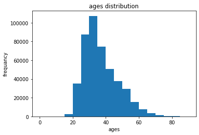

```python
bin_edges = np.arange(0, 95, 5)
plt.hist(df.member_age,bins=bin_edges)
plt.title('ages distribution');
plt.xlabel('ages')
plt.ylabel('frequancy');
```

## (gender counts)

> we can see crearly that male members are more than female the ratio between them close to 3:1

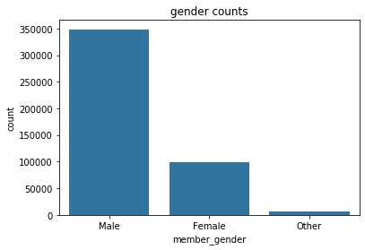

```python
sb.countplot(df.member_gender,color=sb.color_palette()[0])
plt.title('gender counts');
```

## (trips per day)

> tueseday and wednesday have most trips and they so close , while sunday is the lowest

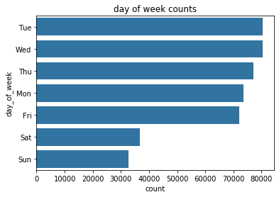

```python
dow_order=df['day_of_week'].value_counts().index
sb.countplot(data=df, y='day_of_week',color=sb.color_palette()[0],order=dow_order);
plt.title('day of week counts');
```

## (distribution of the duration in min)

> as we see its right skewed distribution and most of data below 20 min

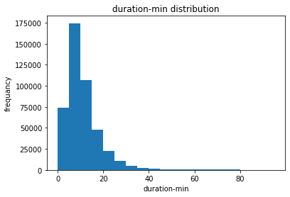

```python
bin_edges = np.arange(0, 100, 5)
plt.hist(df.duration_min, bins=bin_edges);
plt.title('duration-min distribution')
plt.xlabel('duration-min')
plt.ylabel('frequancy');
```

## (the most crowded start station)

[figure not shown]

```python
df.start_station_name.value_counts()[:9].plot(kind='barh');
plt.title('start stations counts')
plt.xlabel('count')
plt.ylabel('top 10 start stations');
```

## (the relation between age and duration)

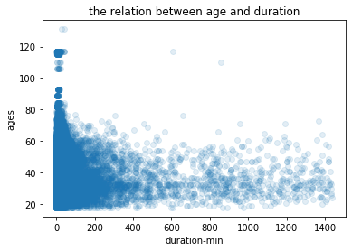

```python
plt.scatter(df['duration_min'],df['member_age'],alpha=1/8)
plt.title('the relation between age and duration')
plt.xlabel('duration-min')
plt.ylabel('ages');
```

## (relation between gender and duration)

> we can notice that others and females have duration time more than male , but the most of riders are males

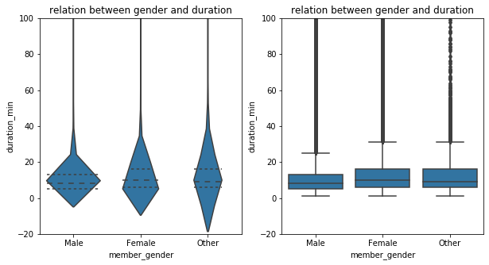

```python
plt.figure(figsize = [10, 5])
plt.subplot(1, 2, 1)
sb.violinplot(data=df,x='member_gender',y='duration_min', inner= 'quartile',color=sb.color_palette()[0]);
plt.ylim(-20,100)
plt.title('relation between gender and duration')
plt.subplot(1, 2, 2)
sb.boxplot(data=df,x='member_gender',y='duration_min',color=sb.color_palette()[0]);
plt.ylim(-20,100)
plt.title('relation between gender and duration');
```

## (gender with user type)

> as we can see the male subscricer is the highest

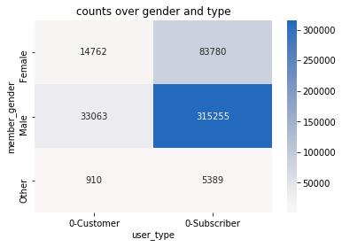

```python
g_t_counts = df.groupby(['user_type', 'member_gender']).size()
g_t_counts = g_t_counts.reset_index()
g_t_counts = g_t_counts.pivot(index = 'member_gender', columns = 'user_type')
sb.heatmap(g_t_counts,annot = True, fmt = 'd',cmap = 'vlag_r', center = 0)
plt.xlabel('user_type');
plt.title('counts over gender and type');
```

## (heat map to see the corr for the numeric columns)

> from 0 to 0.3 that is weak postive relation  
> from 0.3 to 0.7 that is modrate postive relation  
> from 0.7 to 1 that is strong postive relation  
> from 0 to -0.3 that is weak negative relation  
> from -0.3 to -0.7 that is modrate negative relation  
> from -0.7 to -1 that is strong negative relation

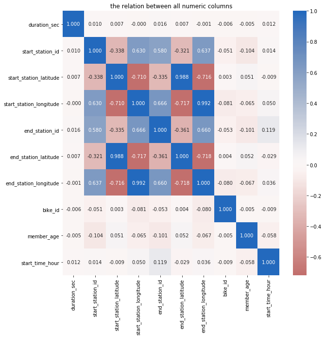

```python
important_vars = ['duration_sec', 'start_time', 'end_time', 'start_station_id', 'start_station_latitude', 'start_station_longitude', 'end_station_id', 'end_station_latitude',
'end_station_longitude', 'bike_id', 'member_age','start_time_hour']
plt.figure(figsize = [10, 10])
sb.heatmap(df[important_vars].corr(), annot = True, fmt = '.3f', cmap = 'vlag_r', center = 0);
plt.title('the relation between all numeric columns');
```

## (day of week with duration and age)

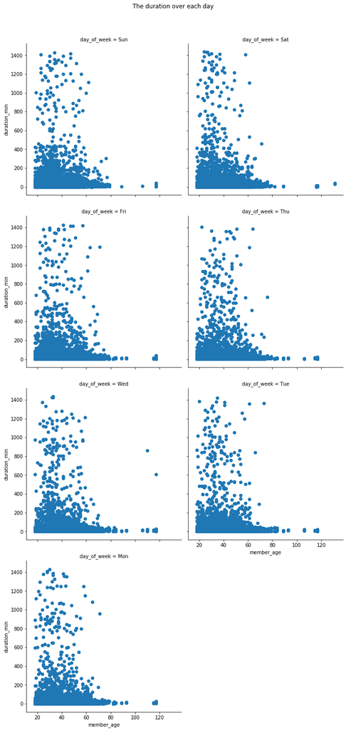

```python
d = sb.FacetGrid(data = df, col = 'day_of_week',  size =5 ,col_wrap = 2,
                margin_titles = True)
d.map(plt.scatter, 'member_age', 'duration_min')
plt.suptitle("The duration over each day", y = 1.04);
plt.tight_layout();
```

## (four dimentions plots with two cat vars and two num vars )

> now we can see females with customers time have no outliers in age and thet have good duration ,the best durations is for male subsribers

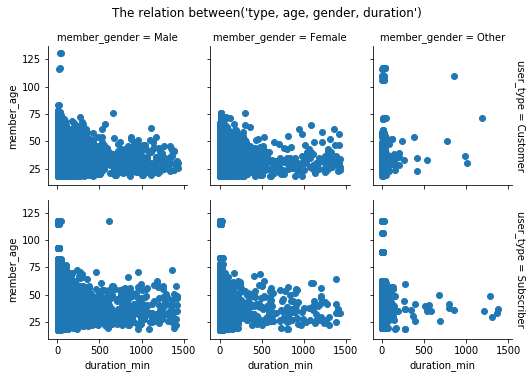

```python
fourd = sb.FacetGrid(data = df, col = 'member_gender', row = 'user_type', size = 2.5,
                margin_titles = True)
fourd.map(plt.scatter, 'duration_min', 'member_age')
plt.suptitle("The relation between('type, age, gender, duration')", y = 1.04);
plt.tight_layout();
```